# Writing a Likelihood Function

## Likelihood

- Likelihood function describes the ‘likelihood’ of the parameters, $\boldsymbol{\theta}$, given the data, $X = \{x_1, \ldots, x_n\}$,

$$L(\boldsymbol{\theta}|X)$$

- Likelihood is the same as the joint density of the data, $f$,

$$f(X) = f(x_1, \ldots, x_n)$$

- Basic understanding of probability required

## Probability Mass Function

- Random variable $x$ is discrete
- Probability mass function $f(x)$ describes probability of r.v. $x$ taking on a specific value.
- Requires that $f(x) \geq 0$ and $\sum_i f(x = i) = 1$.
- Typical Functions: Binomial, Poisson, Negative Binomial

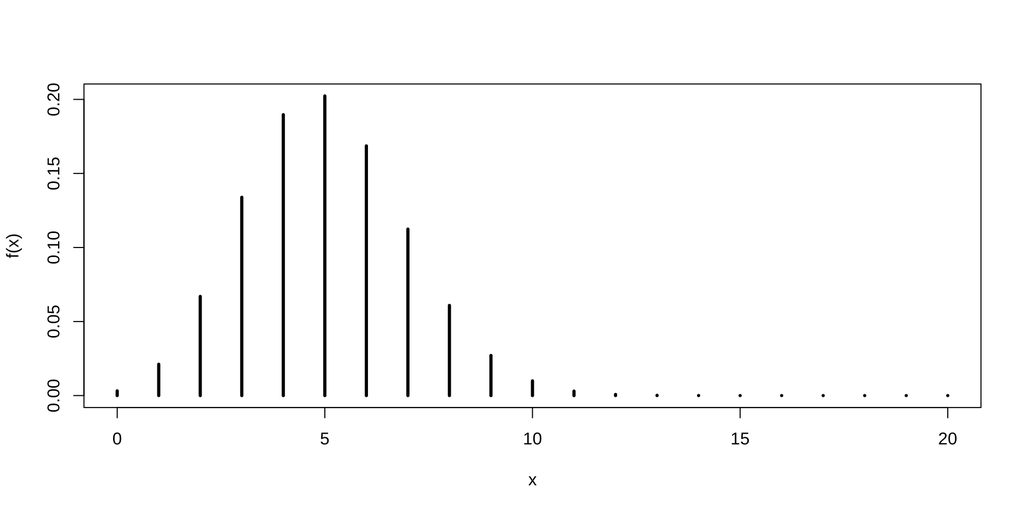

```r
x <- 0:20
fx <- dbinom(x, size = 20, prob = 0.25)
plot(x, fx, ylab = "f(x)", xlab = "x", col = "black", lwd = 3, type = "h")
```

```r
# sum(fx)
```

## Probability Density Function

- Random variable $x$ is continuous
- Probability density function $f(x)$
- Describes a density, not a probability of an event.
- $f(x) \geq 0$ and $\int_{-\infty}^{\infty} f(x)dx = 1$
- Typical Functions: Normal, Student t, Gamma, Beta
- Probability defined by some area under the curve, (CDF)

$$p(x \leq 1) = \int_{-\infty}^1 f(x)dx$$

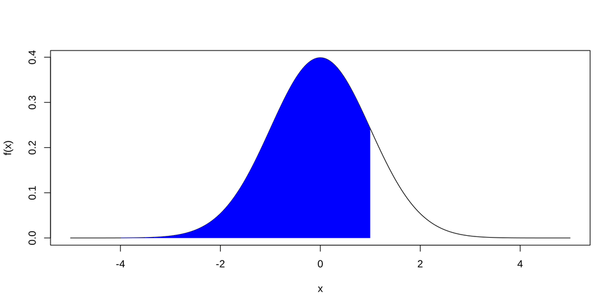

```r
x <- seq(-5, 5, by = 0.01)
fx <- dnorm(x, 0, 1)
plot(x, fx, ylab = "f(x)", xlab = "x", type = "l")
polygon(c(x[x <= 1], 1, 0), c(fx[x <= 1], 0, 0), col="blue", border=NA)
```

```r
# sum(fx*0.01)
```

## Joint Density

- Some sample $\textbf{x}$, of size $n$
- Assume $x_i \sim N(\mu, \sigma)$ and all are independent.
- Then the joint density is
  $$\begin{aligned}
  f(\textbf{x}) & = f(x_1, \ldots, x_n)\\
  & = f(x_1)f(x_2) \cdots f(x_n)\\
  & = \prod_{i=1}^n f(x_i)
  \end{aligned}$$

## Example Discrete

- Draw $30$ observations from a Binomial distribution with size $20$ and probability $0.25$.
- Likelihood is
  $$L(p|\textbf{x}) = f(x_1) \cdots f(x_{30}).$$

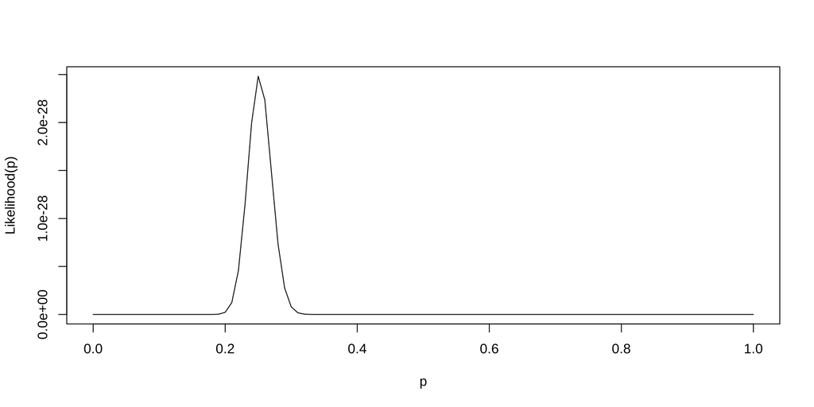

```r
set.seed(1)   ## the simulated data are then the same every time the slides are built
x <- rbinom(30, size = 20, prob = 0.25)
p <- seq(0, 1, 0.01)
lik <- \(p){prod(dbinom(x, prob = p, size = 20))}
likv <- Vectorize(lik)
plot(p, likv(p), type = "l", ylab = "Likelihood(p)")
```

## Example Continuous

- Draw $30$ observations from a Normal distribution with mean $3$ and standard deviation $0.75$.
- Likelihood is
  $$L(\mu, \sigma|\textbf{x}) = f(x_1) \cdots f(x_{30}).$$

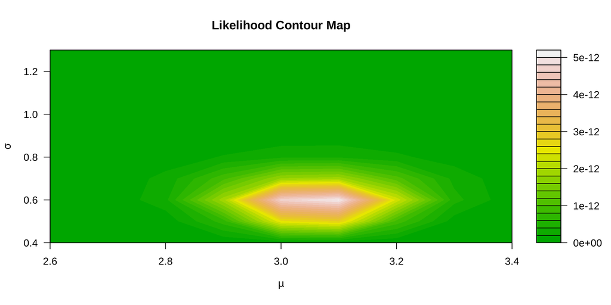

```r
x <- rnorm(30, mean = 3, sd = 0.75)
mu <- seq(2.6, 3.4, 0.1)
sigma = seq(0.4, 1.3, 0.1)
lik <- \(mu, sigma){prod(dnorm(x, mean = mu, sd = sigma))}
likv <- Vectorize(lik, vectorize.args = c("mu", "sigma"))
z <- outer(mu, sigma, likv)
filled.contour(
  x = mu,
  y = sigma,
  z = z,
  color.palette = terrain.colors,
  xlab = expression(mu),
  ylab = expression(sigma),
  main = "Likelihood Contour Map"
)
```

## Conditional Density

- Some sample $\textbf{x}$, of size $n$
- Assume $x_i|u \sim N(u + \mu, \sigma)$
- $u \sim N(0, 1)$ is a random variable (e.g. random effect)
- The $x$ values are not independent!

$$f(\textbf{x}) \neq \prod_{i=1}^n f(x_i)$$

- However, conditional on the value of $u$, they are independent,

$$f(\textbf{x}|u) = \prod_{i=1}^n f(x_i|u)$$

- Joint density can be written as

$$f(\textbf{x}) = \int f(\textbf{x},u)du = \int f(\textbf{x}|u)f(u)du$$

## Conditional Density

- How we write hierarchical models, for some group $j$,

$$\begin{align}
x_{i} & = \mu + u_{j} + \epsilon_i \\
u_j & \sim N(0, \sigma_u^2) \\
\epsilon_i & \sim N(0, \sigma^2)
\end{align}$$

- Observations within a group $j$ are not independent.
- Conditional on the value of the random effect $u_j$ they are!

## Likelihood

- For parameters $\boldsymbol{\theta} = \{\mu, \sigma\}$
- Assuming independence between observations $x_1, \ldots, x_n$

$$L(\boldsymbol{\theta} | \textbf{x}) = \prod_{i=1}^n f(x_i)$$

- Maximum likelihood estimation – Find maximum values of parameters given the data.

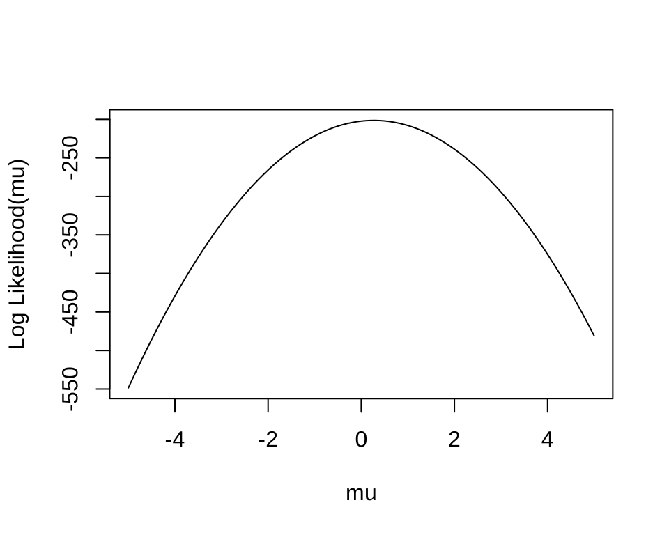

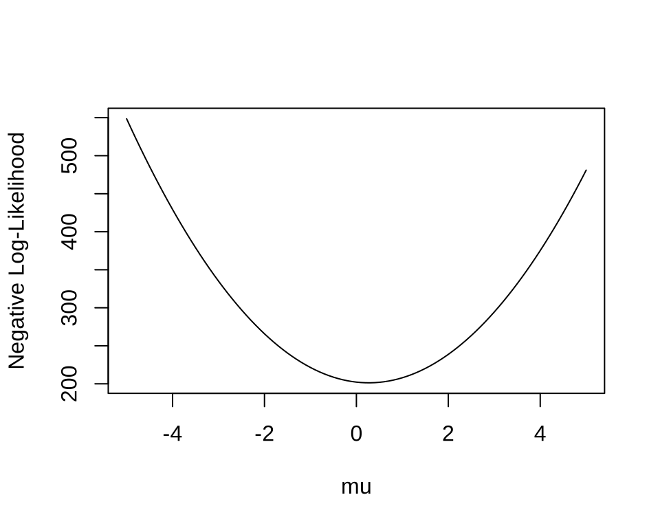

## Fitting a Likelihood in R

- Maximum of likelihood is also maximum of log-likelihood
- Maximization is the same as minimizing the negative.
- Multiplying small numbers is bad.
- $l(\boldsymbol{\theta}|\mathbf{x}) = \log(L(\boldsymbol{\theta}|\mathbf{x}))$

```r
  x <- rnorm(1000, 0, 5)
  fx <- dnorm(x, 0, 5)
  log(prod(fx))
```

```
[1] -Inf
```

```r
  sum(log(fx))
```

```
[1] -3079.63
```

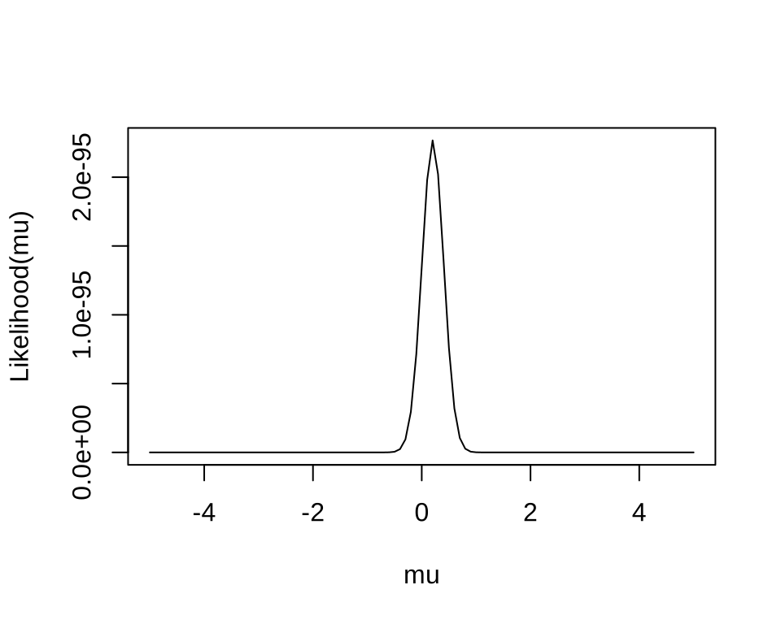

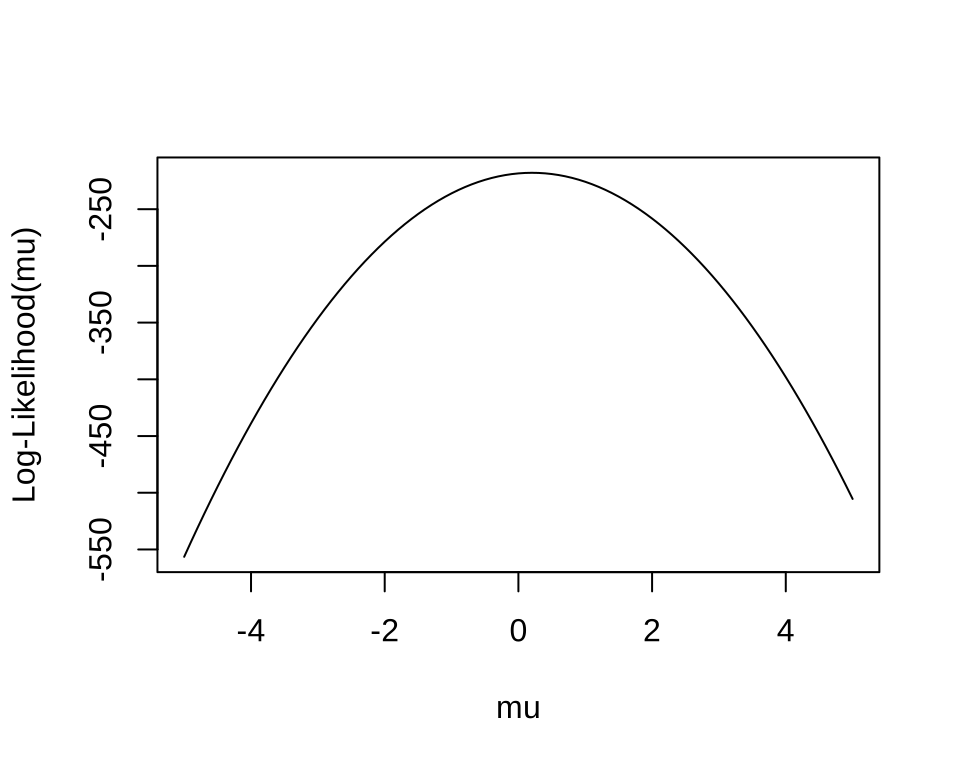

## Fitting a Likelihood in R

- Remember that $\log(AB) = \log(A) + \log(B)$
- We build the log-likelihood by summing over the log of each independent component of the likelihood.

$$\log(L(\boldsymbol{\theta}|\mathbf{x}) = \sum \log(f(x_i)).$$

- In R this is best done vectorized. Loops are slow, especially when nested.
- In C++ loops are very fast.

```r
  library(RTMB)   ## more on this in a moment
  x <- rnorm(1000, 0, 5)
  ## Log-likelihood of the mean (sd known), written two ways
  ll_vec <- \(mu){
    lfx <- dnorm(x, mu, 5, log = TRUE)
    sum(lfx)
  }
  ll_loop <- \(mu){
    ll <- 0
    for( i in 1:1000){
      ll <- ll + dnorm(x[i], mu, 5, log = TRUE)
    }
    ll
  }

  ## First taste of RTMB... :)
  ## The calculation has to depend on the input `mu`: anything that does not
  ## is worked out once, while taping, and stored as a constant.
  ll_loopc <- MakeTape(ll_loop, 0)
  ll_vecc <- MakeTape(ll_vec, 0)

  microbenchmark::microbenchmark(
    vectorized = ll_vec(rnorm(1)),
    looped = ll_loop(rnorm(1)),
    looped_c = ll_loopc(rnorm(1)),
    vectorized_c = ll_vecc(rnorm(1)),
    times = 100
  )
```

```
Unit: microseconds
         expr      min        lq       mean    median        uq       max neval
   vectorized   23.666   26.0520  170.69885   29.9445   34.3115 13986.716   100
       looped 3911.582 4084.7355 4836.83248 4149.3655 4381.3325 15587.844   100
     looped_c   21.967   23.6335   40.09124   39.7170   54.0890    77.718   100
 vectorized_c   23.037   24.3830   43.70372   39.0215   63.4295   107.185   100
```

## Likelihood in R

- Consider a sample of size 50 of $x \sim N(\mu = 2, \sigma = 5)$

```r
x <- rnorm(50, 2, 5)

negloglik <- \(theta){
  mu <- theta[1]
  sigma <- theta[2]
  ll <- sum(dnorm(x, mu, sigma, log = TRUE))
  return(-ll)
}
```

- Problems with this code?

## Link functions

- Optimization typically wants no discontinuities in parameter space.
- We know standard deviation is strictly positive $\sigma > 0$
- $\log$ maps a positive number to $(-\infty, \infty)$
  - Inverse is $\exp$
- If $p \in [0,1]$, then $p/(1-p) \in [0, \infty)$
- $\alpha = \text{logit}(p) = \log(p/(1-p)) \in (-\infty, \infty)$
  - Inverse is $p = 1/(1+\exp(-\alpha))$

```r
negloglik <- \(theta){
  mu <- theta[1]
  sigma <- exp(theta[2])
  ll <- sum(dnorm(x, mu, sigma, log = TRUE))
  return(-ll)
}
```

## Writing a Likelihood in RTMB

```r
library(RTMB)

negloglik <- \(theta){
  getAll(theta)
  sigma <- exp(logsigma)
  ll <- sum(dnorm(x, mu, sigma, log = TRUE))
  return(-ll)
}

pars <- list(mu = 0, logsigma = 0)
negloglik(pars)
```

```
[1] 677.6366
```

```r
obj <- MakeADFun(negloglik, pars)
obj$fn(c(0,0))
```

```
[1] 677.6366
```

```r
-sum(dnorm(x, 0, exp(0), log = TRUE))   ## always check against plain R
```

```
[1] 677.6366
```

```r
microbenchmark::microbenchmark(
  R = negloglik(list(mu = rnorm(1), logsigma = rnorm(1))),
  RTMB = obj$fn(rnorm(2))
)
```

```
Unit: microseconds
 expr    min      lq     mean median      uq     max neval
    R 14.120 15.1055 23.65027 15.768 18.2445 446.691   100
 RTMB 12.681 13.2835 17.87501 14.021 16.0290 223.448   100
```

## Practical

- Make your sockeye Ricker model run as an `RTMB` function
- Can log productivity be any values?
- Can the density dependence parameter be negative?
- Note
  - `getAll` attaches list to environment.
  - Pass inputs as list of named variables
  - `MakeADFun` creates TMB object
  - Get to `obj = MakeADFun(negloglik, parameters)`
  - Run `obj$fn()`

## End of Module

- Take home:
  - reminder of fundamental statistics
  - write basic likelihoods in R
  - basic numerical thoughts
- Questions?